# CollaborativeFiltering

```python
import matplotlib.pyplot as plt
import numpy as np
import seaborn as sns
import pandas as pd
import pickle
from scipy.spatial.distance import cosine
from sklearn.linear_model import LinearRegression
import itertools
import time
from scipy.sparse import csr_matrix
from sklearn.metrics.pairwise import cosine_similarity
import logging
from sklearn.model_selection import train_test_split
from scipy.sparse import csr_matrix, csc_matrix, lil_matrix
from sklearn.metrics import mean_squared_error
```

## Load Dataset:

```python
item_df = pd.read_pickle("item_df.pkl")
item_df.info()
```

```
<class 'pandas.core.frame.DataFrame'>
RangeIndex: 466007 entries, 0 to 466006
Data columns (total 10 columns):
 #   Column                  Non-Null Count   Dtype
---  ------                  --------------   -----
 0   user_id                 466007 non-null  object
 1   business_id             466007 non-null  object
 2   review_id               466007 non-null  object
 3   name_business           466007 non-null  object
 4   name_user               466007 non-null  object
 5   review_count_business   466007 non-null  int64
 6   review_count_user       466007 non-null  int64
 7   average_stars_user      466007 non-null  float64
 8   average_stars_business  466007 non-null  float64
 9   stars_review            466007 non-null  float64
dtypes: float64(3), int64(2), object(5)
memory usage: 35.6+ MB
```

**Description of Dataset:**

Every record corresponds to a unique review.

- `review_id` unique value for each review
- `user_id` unique value for each user
- `business_id` unique value for each business
- `name_business` name of the business
- `name_user` name of the user
- `review_count_business` the number of reviews made for a business
- `review_count_user` the number of reviews made by a user
- `average_stars_user` the average star rating of each user
- `average_stars_business` the average star rating of the business
- `stars_review` the star rating of the specific review

### Will Only Look at Users with at least 10 Reviews in New Orleans:

```python
# Add the review count as a new column in avg_df
user_review_counts = item_df['user_id'].value_counts()
item_df['review_count_user_NO'] = item_df['user_id'].map(user_review_counts)
```

```python
print("Total Number of Reviews", item_df.shape[0])
print("Users in this set", item_df['user_id'].unique().shape[0], "Restaurants", item_df['business_id'].unique().shape[0])
item_df.tail()
```

```
Total Number of Reviews 466007
Users in this set 201798 Restaurants 2260
```

|  | user_id | business_id | review_id | name_business | name_user | review_count_business | review_count_user | average_stars_user | average_stars_business | stars_review | review_count_user_NO |
| --- | --- | --- | --- | --- | --- | --- | --- | --- | --- | --- | --- |
| 466002 | zzsqjDvanJhH9tn8NautOQ | 3q9-zixznvM6aj8XKYd6lg | OnZYwx6G1jeHhtUqrRD6tQ | Tasty Treat Food Truck | Indigo | 51 | 2 | 3.00 | 3.0 | 1.0 | 2 |
| 466003 | zzsqjDvanJhH9tn8NautOQ | a1u9Bxrq_fZxl2pgqQUcJA | VI8F9YI5es0CRXWXbnkang | The Governor | Indigo | 330 | 2 | 3.00 | 4.5 | 5.0 | 2 |
| 466004 | zzuIXWg1WRhQXheMIdGZ5w | Nq_suBLLeDKjND6efdNINg | 9UsY8QLX31sDUi3q48fIyw | CC's Coffee House | Sarah | 67 | 3 | 4.33 | 4.0 | 5.0 | 2 |
| 466005 | zzuIXWg1WRhQXheMIdGZ5w | XnQ84ylyAZwh-XfHGGNBbQ | 2N6onaK3EKUdAgxBE8FIUA | Coop's Place | Sarah | 3157 | 3 | 4.33 | 3.5 | 3.0 | 2 |
| 466006 | zzxZoMmjbUjXcWZzrE3PIw | VaO-VW3e1kARkU9bP1E7Fw | R6VXlxtCn-6ZVlCS8us9Iw | Felix's Restaurant & Oyster Bar | Sherry | 3966 | 9 | 2.40 | 4.0 | 5.0 | 1 |

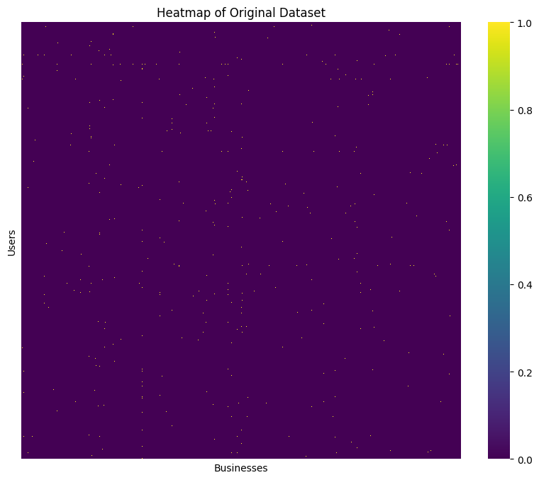

```python
def create_sparse_matrix(df):
    """ Convert DataFrame into a sparse ratings matrix """
    df['user_id'] = df['user_id'].astype("category")
    df['business_id'] = df['business_id'].astype("category")

    row = df['user_id'].cat.codes
    col = df['business_id'].cat.codes
    data = df['stars_review'].values
    sparse_matrix = csr_matrix((data, (row, col)), shape=(df['user_id'].cat.categories.size, df['business_id'].cat.categories.size))

    return sparse_matrix

def plot_heatmap(matrix, title):
    plt.figure(figsize=(10, 8))
    sns.heatmap(matrix, vmin=0, vmax=1, cmap='viridis', xticklabels=False, yticklabels=False)
    plt.title(title)
    plt.xlabel('Businesses')
    plt.ylabel('Users')
    plt.show()

# Plotting the heatmaps
# Create sparse matrices
sparse_matrix_original = create_sparse_matrix(item_df)
dense_matrix_original = sparse_matrix_original.toarray()
plot_heatmap(dense_matrix_original, 'Heatmap of Original Dataset')
```

```python
# filter to only users and businesses with at least 10 reviews
filtered_df = item_df[
        (item_df['review_count_user_NO'] > 10) &
        (item_df['review_count_business'] > 10)
    ].copy()
```

```python
print("Total Number of Reviews", filtered_df.shape[0])
print("Users in this set", filtered_df['user_id'].unique().shape[0], "Restaurants", filtered_df['business_id'].unique().shape[0])
filtered_df.tail()
```

```
Total Number of Reviews 95137
Users in this set 3978 Restaurants 1926
```

|  | user_id | business_id | review_id | name_business | name_user | review_count_business | review_count_user | average_stars_user | average_stars_business | stars_review | review_count_user_NO |
| --- | --- | --- | --- | --- | --- | --- | --- | --- | --- | --- | --- |
| 465980 | zzawiLRYd4TjHKVyx6zjUQ | QE2KzOMx80dUIkW7NNiH6w | eEHdtNxv4lQ3XTLTtnmQnA | Coco Hut | Kierstin | 76 | 58 | 2.46 | 4.5 | 5.0 | 12 |
| 465981 | zzawiLRYd4TjHKVyx6zjUQ | RC5DvxYvcR_RXfefEHJIMQ | zybajkBc28-gJ34Vh5ybAA | Soul's Seafood Market | Kierstin | 17 | 58 | 2.46 | 4.0 | 5.0 | 12 |
| 465982 | zzawiLRYd4TjHKVyx6zjUQ | UGefDZNmnBztS0eoXWtHyQ | A_8K3RSt1b524Oy9GB__Kg | The Joint | Kierstin | 1335 | 58 | 2.46 | 4.5 | 5.0 | 12 |
| 465983 | zzawiLRYd4TjHKVyx6zjUQ | ac1AeYqs8Z4_e2X5M3if2A | 5qsh2olWT1eR6DLe0d_Oaw | Oceana Grill | Kierstin | 7400 | 58 | 2.46 | 4.0 | 5.0 | 12 |
| 465984 | zzawiLRYd4TjHKVyx6zjUQ | kIMT0HWye1apfTH1-ITQAA | 3VonlN8zj76PaG17dwB1TQ | Hanks Supermarket | Kierstin | 79 | 58 | 2.46 | 3.5 | 3.0 | 12 |

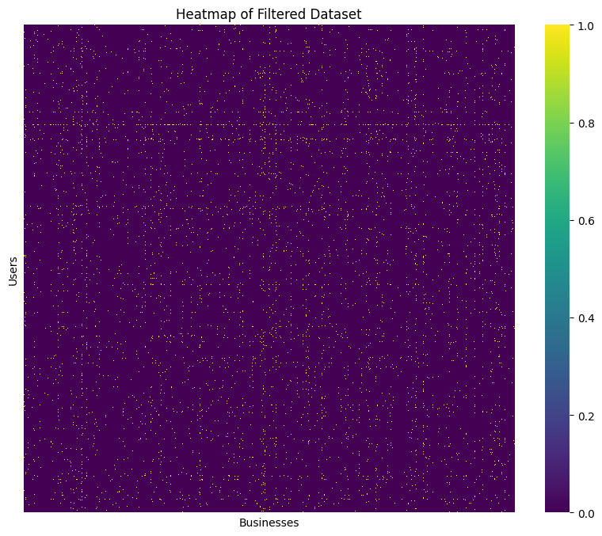

```python
# Plotting the heatmaps
sparse_matrix_filtered = create_sparse_matrix(filtered_df)
dense_matrix_filtered = sparse_matrix_filtered.toarray()
plot_heatmap(dense_matrix_filtered, 'Heatmap of Filtered Dataset')
```

## Train-test Splits

```python
from scipy.sparse import csr_matrix, lil_matrix

def create_rating_matrix(dataframe, user_field='user_id', item_field='business_id', rate_field='stars_review'):
    """
    Construct a sparse matrix from rating data.
    """
    # Convert user and item IDs to categorical codes for matrix creation
    dataframe[user_field] = dataframe[user_field].astype("category")
    dataframe[item_field] = dataframe[item_field].astype("category")

    # Assign rows to users and columns to items with corresponding ratings
    user_indices = dataframe[user_field].cat.codes
    item_indices = dataframe[item_field].cat.codes
    ratings = dataframe[rate_field].values
    rating_matrix = csr_matrix((ratings, (user_indices, item_indices)),
                               shape=(dataframe[user_field].cat.categories.size, dataframe[item_field].cat.categories.size))

    return rating_matrix, dataframe[user_field].cat.categories, dataframe[item_field].cat.categories

def split_rating_data(rating_matrix, val_reviews=2, test_reviews=2, seed=42):
    """
    Divide a ratings matrix into distinct training, validation, and testing sets.
    """
    np.random.seed(seed)  # For reproducibility

    num_users = rating_matrix.shape[0]
    rated_rows, rated_cols = rating_matrix.nonzero()

    # lil_matrix format for easier manipulation
    train_matrix = lil_matrix(rating_matrix.copy())
    test_matrix = lil_matrix(rating_matrix.shape)
    validation_matrix = lil_matrix(rating_matrix.shape)

    for user in range(num_users):
        # Identify all rated items by this user
        user_ratings = rated_cols[rated_rows == user]
        np.random.shuffle(user_ratings)  # Randomize item indices

        # Determine indices for test and validation sets
        test_indices = user_ratings[-test_reviews:]
        val_indices = user_ratings[-(test_reviews + val_reviews):-test_reviews]
        train_indices = user_ratings[:-(test_reviews + val_reviews)]

        # Populate the test and validation matrices
        test_matrix[user, test_indices] = rating_matrix[user, test_indices]
        validation_matrix[user, val_indices] = rating_matrix[user, val_indices]

        # Clear the selected test and validation ratings from the training matrix
        train_matrix[user, test_indices] = 0
        train_matrix[user, val_indices] = 0

    # Convert matrices back to csr format after assignment
    train_matrix = train_matrix.tocsr()
    test_matrix = test_matrix.tocsr()
    validation_matrix = validation_matrix.tocsr()

    # Ensure no overlap between training, validation, and test data
    assert (train_matrix.multiply(validation_matrix).nnz == 0)
    assert (train_matrix.multiply(test_matrix).nnz == 0)
    assert (validation_matrix.multiply(test_matrix).nnz == 0)

    return train_matrix, validation_matrix, test_matrix

sparse_matrix, user_categories, item_categories = create_rating_matrix(filtered_df, user_field='user_id', item_field='business_id', rate_field='stars_review')
sparse_matrix_train, sparse_matrix_val, sparse_matrix_test = split_rating_data(rating_matrix, seed=42)
```

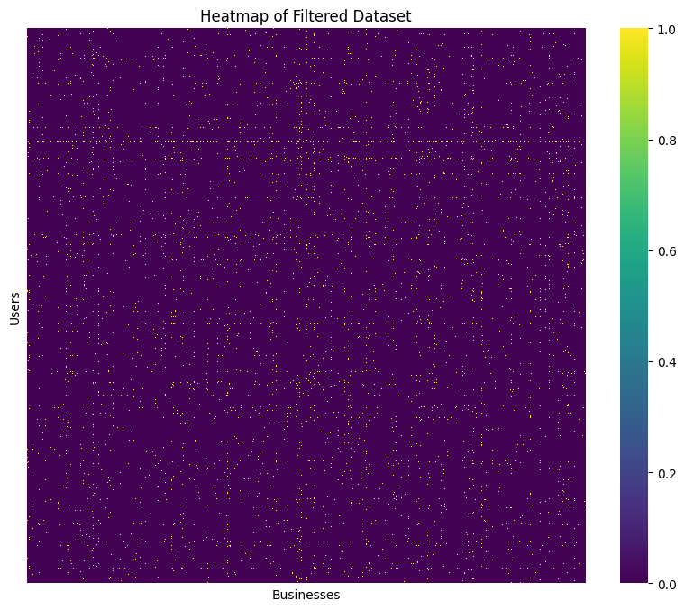

```python
# Plotting the heatmaps
dense_matrix = sparse_matrix_train.toarray()
plot_heatmap(dense_matrix, 'Heatmap of Filtered Dataset')
```

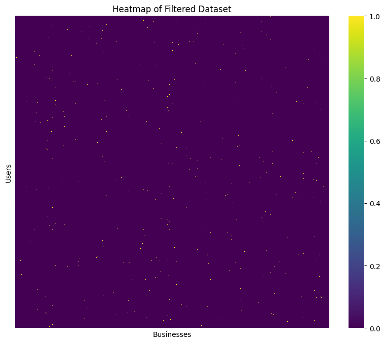

```python
dense_matrix = sparse_matrix_val.toarray()
plot_heatmap(dense_matrix, 'Heatmap of Filtered Dataset')
```

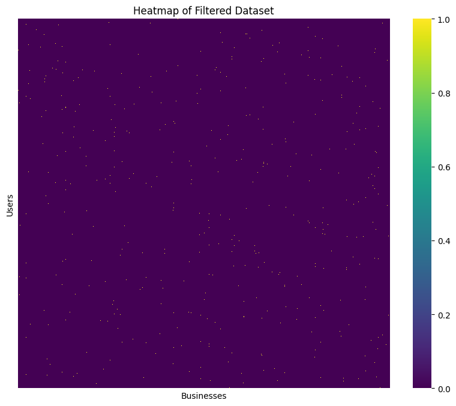

```python
dense_matrix = sparse_matrix_test.toarray()
plot_heatmap(dense_matrix, 'Heatmap of Filtered Dataset')
```

- Computing similarity using basic cosine measure in item-based case has one important drawback - the differences in rating scale between different users are not taken into account.
- The adjusted cosine similarity offsets this drawback by subtracting the corresponding user average from each co-rated pair
- Formally, the similarity between items i and j using this scheme is given by:

[figure not shown]

**Make item_item cosine similarity matrix**

**Function to compute user-user or item-item similarity for a given dataset**

```python
def similarity_matrix(train_matrix, between='users'):
    '''Returns the cosine similarity between users or items'''
    if between == 'users':
        similarity = train_matrix @ train_matrix.T
    else:
        similarity = train_matrix.T @ train_matrix
    similarity_dense = similarity.toarray() + 1e-8
    norm_array = np.sqrt(np.diag(similarity_dense))
    return similarity_dense / norm_array / norm_array.reshape(-1, 1)
```

```python
# Create ratings matrix
# Compute item-item similarity matrix from the training set
item_similarity_matrix = similarity_matrix(sparse_matrix_train, between='item')

# Compute user-user similarity matrix from the training set
user_similarity_matrix = similarity_matrix(sparse_matrix_train, between='user')
```

```python
user_similarity_matrix.shape
```

[output not shown]

## KNN

```python
def knearest(similarity, k=40, kind='user'):
    """
    Find k-nearest neighbors based on similarity matrix.

    Args:
    - similarity: 2D numpy array of item-to-item or user-to-user similarities.
    - k: Number of nearest neighbors to consider.
    - kind: 'user' for user-user similarity, 'item' for item-item similarity.

    Returns:
    - An array containing indices of k-nearest neighbors for each item or user.
    """
    n = similarity.shape[0]
    nearest = np.zeros((n, k), dtype=int)

    for i in range(n):
        if kind == 'user':
            top_k_indices = np.argsort(similarity[i])[-k-1:-1]
            nearest[i, :] = top_k_indices[top_k_indices != i]  # Exclude self
        else:
            top_k_indices = np.argsort(similarity[:, i])[-k-1:-1]
            nearest[i, :] = top_k_indices[top_k_indices != i]  # Exclude self

    return nearest
```

## Predict Ratings

```python
def predict_ratings_knn(ratings, similarity, kind='user', k=40):
    """
    Predict ratings based on top-k similar users or items.

    Args:
    - ratings: numpy matrix of ratings (businesses x users), already dense.
    - similarity: Dense numpy array of item-item or user-user similarities.
    - kind: 'user' for user-user similarity, 'item' for item-item similarity.
    - k: Number of nearest neighbors to consider.

    Returns:
    - pred: numpy matrix of predicted ratings.
    """
    # Get the number of users and items from the ratings matrix
    n_users, n_items = ratings.shape

    # Initialize the prediction matrix with zeros
    pred = np.zeros(ratings.shape)

    # If using user-based collaborative filtering
    if kind == 'user':
        # Calculate the average rating for each user
        user_bias = np.mean(ratings, axis=1)

        # Normalize the ratings by subtracting the user bias
        normalized_ratings = ratings - user_bias.reshape(-1, 1)

        # Loop over each user
        for i in range(n_users):
            # Set the similarity of the user with themselves to a very low value to exclude it
            similarity[i, i] = -np.inf

            # Get the indices of the top-k most similar users
            top_k_users = np.argsort(similarity[i])[:-k-1:-1]

            # Ensure the indices are within valid range
            top_k_users = top_k_users[top_k_users < n_users]

            # Get the similarity weights of the top-k users
            weights = similarity[i, top_k_users]

            # If the sum of absolute weights is not zero, calculate the predicted ratings
            if np.sum(np.abs(weights)) != 0:
                pred[i] = np.dot(weights, normalized_ratings[top_k_users]) / np.sum(np.abs(weights))

        # Add the user bias back to the predictions
        pred += user_bias.reshape(-1, 1)

    # If using item-based collaborative filtering
    else:
        # Calculate the average rating for each item
        item_bias = np.mean(ratings, axis=0)

        # Normalize the ratings by subtracting the item bias
        normalized_ratings = ratings - np.tile(item_bias, (ratings.shape[0], 1))

        # Loop over each item
        for j in range(n_items):
            # Set the similarity of the item with itself to a very low value to exclude it
            similarity[j, j] = -np.inf

            # Limit k to the actual number of items minus one to avoid self-indexing
            max_k = min(k, n_items - 1)

            # Get the indices of the top-k most similar items
            sorted_indices = np.argsort(similarity[:, j])
            top_k_items = sorted_indices[-max_k:]  # Get top k indices safely

            # Get the similarity weights of the top-k items
            weights = similarity[top_k_items, j]

            # Get the normalized ratings for the top-k items
            sub_ratings = normalized_ratings[:, top_k_items]

            # If the sum of absolute weights is not zero, calculate the predicted ratings
            if np.sum(np.abs(weights)) != 0:
                pred[:, j] = np.dot(weights, sub_ratings.T) / np.sum(np.abs(weights))

        # Add the item bias back to the predictions
        pred += np.tile(item_bias, (ratings.shape[0], 1))

    # Return the predicted ratings matrix
    return pred
```

**Testing Functions:**

```python
# variables values for testing:
valid_business_indices = train_df['business_id'].unique()

target_business_id = '-0__F9fnKt8uioCKztF5Ww'
target_user_id = '005GchcM1HWBH3SFKrIxBA'
k = 10  # Number of neighbors
alpha = 0  # Regularization parameter
```

**knearest:**

```python
start_time = time.time()
neighbors = knearest(item_similarity_matrix, k=10, kind='item')
end_time = time.time()
print("Nearest Neighbors: \n", neighbors)
print("Time taken:", end_time - start_time, "seconds")
```

[output not shown]

**RMSE vs K**

```python
def calculate_rmse(pred, actual):
    """
    Calculate the root mean square error between predicted and actual ratings.
    """
    if isinstance(actual, (csr_matrix, csc_matrix)):
        actual = actual.todense()

    mask = actual != 0
    pred = np.asarray(pred)[mask].flatten()
    actual = np.asarray(actual)[mask].flatten()
    rmse = np.sqrt(mean_squared_error(actual, pred))
    return rmse
```

```python
def test_k_values(train_matrix, val_matrix, similarity_matrix, kind='item', max_k=40):
    """
    Test various k values for prediction and plot the RMSE for each k.
    """
    train_errors = []
    val_errors = []
    k_values = range(1, max_k + 1, 2)

    if isinstance(train_matrix, (csr_matrix, csc_matrix)):
        train_matrix = train_matrix.todense()
    if isinstance(val_matrix, (csr_matrix, csc_matrix)):
        val_matrix = val_matrix.todense()

    for k in k_values:
        # Predict ratings using the top-k neighbors for training set
        preds_train = predict_ratings_knn(train_matrix, similarity_matrix, kind=kind, k=k)
        rmse_train = calculate_rmse(preds_train, train_matrix)
        train_errors.append(rmse_train)

        # Predict ratings using the top-k neighbors for validation set
        preds_val = predict_ratings_knn(val_matrix, similarity_matrix, kind=kind, k=k)
        rmse_val = calculate_rmse(preds_val, val_matrix)
        val_errors.append(rmse_val)

        # print(f"k={k}: Train RMSE={rmse_train}, Validation RMSE={rmse_val}")

    # Find the k with the lowest RMSE for both train and validation sets
    best_k_train = k_values[np.argmin(train_errors)]
    best_rmse_train = min(train_errors)
    best_k_val = k_values[np.argmin(val_errors)]
    best_rmse_val = min(val_errors)

    print(f"Best k for Train RMSE: k={best_k_train}, RMSE={best_rmse_train}")
    print(f"Best k for Validation RMSE: k={best_k_val}, RMSE={best_rmse_val}")

    # Plot RMSE vs. k values
    plt.figure(figsize=(10, 6))
    plt.plot(k_values, train_errors, marker='o', linestyle='-', color='b', label='Train RMSE')
    plt.plot(k_values, val_errors, marker='o', linestyle='-', color='r', label='Validation RMSE')
    plt.title('RMSE vs. Number of Neighbors (k)')
    plt.xlabel('k (Number of Neighbors)')
    plt.ylabel('Root Mean Square Error (RMSE)')
    plt.legend()
    plt.grid(True)
    plt.show()
```

```
Best k for Train RMSE: k=7, RMSE=3.202318921439017
Best k for Validation RMSE: k=7, RMSE=4.100234271709099
```

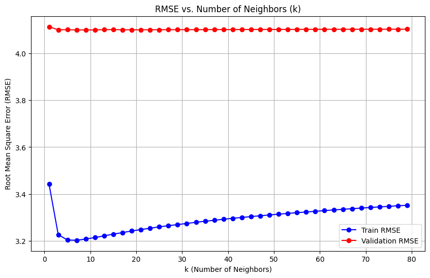

```
Best k for Train RMSE: k=9, RMSE=3.507629618658356
Best k for Validation RMSE: k=13, RMSE=4.111939929816658
```

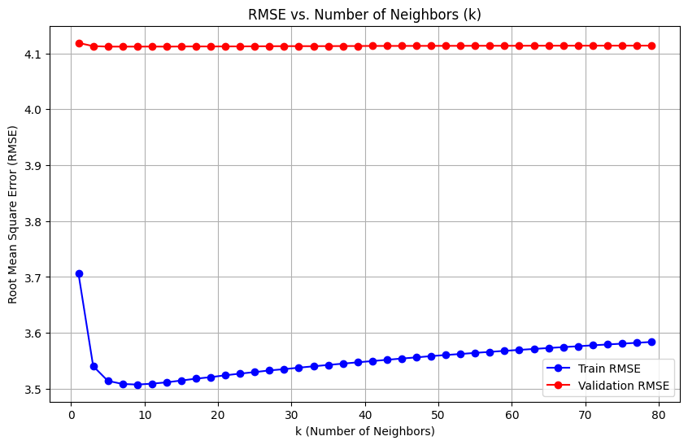

```python
user_similarity_matrix = similarity_matrix(sparse_matrix_train, between='users')
item_similarity_matrix = similarity_matrix(sparse_matrix_train, between='items')

dense_matrix_train = sparse_matrix_train.todense()
dense_matrix_val = sparse_matrix_val.todense()

# Test with user-based similarity
test_k_values(dense_matrix_train, dense_matrix_val, user_similarity_matrix, kind='user', max_k=80)

# Test with item-based similarity
test_k_values(dense_matrix_train, dense_matrix_val, item_similarity_matrix, kind='item', max_k=80)
```

## Making Recommendations

```python
def usernamefromid(df, user_id):
    if user_id in df['user_id'].values:
        return df[df.user_id == user_id]['name_user'].iloc[0]
    else:
        return "Unknown User"

def biznamefromid(df, business_id):
    if business_id in df['business_id'].values:
        return df[df.business_id == business_id]['name_business'].iloc[0]

def get_top_n_recommendations(df, user_id, user_categories, item_categories, ratings_matrix, similarity_matrix, filtered_df, kind='user', k=40, N=5):
    """
    Get the top N business recommendations for a given user.
    """
    # Get the index of the user in the ratings matrix
    user_idx = user_categories.get_loc(user_id)

    # Predict ratings for all users or items
    pred_ratings = predict_ratings_knn(ratings_matrix, similarity_matrix, filtered_df, kind=kind, k=k)

    # Get the predicted ratings for the given user
    user_pred_ratings = pred_ratings[user_idx, :]

    # Find businesses that the user has not rated yet
    user_actual_ratings = np.asarray(ratings_matrix[user_idx, :]).flatten()
    unrated_indices = np.where(user_actual_ratings == 0)[0]

    # Get the predicted ratings for unrated businesses
    unrated_predictions = user_pred_ratings[unrated_indices]

    # Get the indices of the top N recommendations
    top_n_indices = np.argsort(unrated_predictions)[-N:][::-1]

    # Map back to business IDs
    top_n_business_ids = item_categories[unrated_indices[top_n_indices]]
    top_n_ratings = unrated_predictions[top_n_indices]

    # Map business IDs to business names
    top_n_business_names = [biznamefromid(df, biz_id) for biz_id in top_n_business_ids]

    # Create a DataFrame to return
    top_n_recommendations = pd.DataFrame({
        'business_id': top_n_business_ids,
        'business_name': top_n_business_names,
        'predicted_rating': top_n_ratings
    })

    # Print the top recommendations for the user
    user_name = usernamefromid(df, user_id)
    print(f"Top Recommendations for {user_name}:")

    return top_n_recommendations
```

```python
sparse_matrix, user_categories, item_categories = create_rating_matrix(filtered_df, user_col='user_id', item_col='business_id', rating_col='stars_review')
sparse_matrix_train, sparse_matrix_val, sparse_matrix_test = split_rating_data(sparse_matrix, random_seed=42)

# Compute the user-user and item-item similarity matrices
user_similarity_matrix = similarity_matrix(sparse_matrix_train, between='users')
item_similarity_matrix = similarity_matrix(sparse_matrix_train, between='items')

# Convert sparse matrices to dense for prediction
dense_matrix_train = sparse_matrix_train.todense()
dense_matrix_val = sparse_matrix_val.todense()

# Get the top N recommendations for a given user
user_id = 'zLWaI3RP0IFCwMAERFRR0Q'
top_n_recommendations = get_top_n_recommendations(filtered_df, user_id, user_categories, item_categories, dense_matrix_train, user_similarity_matrix, filtered_df, kind='user', k=40, N=5)

print(top_n_recommendations)
```

```
Top Recommendations for Rowan:
              business_id   business_name  predicted_rating
0  2DTkzhmMpv5fIPKheePClA           Shaya          5.133887
1  gTC8IQ_i8zXytWSly3Ttvg  Cochon Butcher          5.107080
2  hfbZ97Te3T4jeWN6GgsGrQ      Willa Jean          5.054042
3  5xRmemqmR89BpGoOA25hqA        Dian Xin          4.923570
4  Vz2RN55rTJBGn43K1v84nA        Domenica          4.900654
```

```python
top_n_recommendations = get_top_n_recommendations(filtered_df, user_id, user_categories, item_categories, dense_matrix_train, item_similarity_matrix, kind='item', k=40, N=5)
print(top_n_recommendations)
```

```
Top Recommendations for Rowan:
              business_id                business_name  predicted_rating
0  KLLO4MTEI2mDwdakz51www  Picnic Provisions & Whiskey          1.802119
1  zI0OdjkdQqD7az8aM6ppdg                     Cho Thai          1.645797
2  wtwDcp79klLOLaIjCFHQCA                 Saffron nola          1.597243
3  5xRmemqmR89BpGoOA25hqA                     Dian Xin          1.556385
4  QIYVaE6qrgAYHV6aJhqfJQ                          Saj          1.470133
```

## Adding Baseline to Predictions

**Baseline Subtraction**

- Adjust for user and item biases when computing predicted ratings in a collaborative filtering system.

```python
def predict_ratings_knn(ratings, similarity, kind='user', k=40):
    """
    Predict ratings based on top-k similar users or items with baseline adjustment.
    """
    n_users, n_items = ratings.shape
    pred = np.zeros(ratings.shape)

    # Calculate the global average rating only for non-zero ratings
    global_avg = np.mean(ratings[ratings > 0])
    # print(f"Ratings shape: {ratings.shape}")
    # print(f"Global average rating: {global_avg}")

    if kind == 'user':
        user_bias = np.mean(ratings, axis=1).reshape(-1, 1) - global_avg
        # print(f"User bias shape: {user_bias.shape}")

        for i in range(n_users):
            similarity[i, i] = -np.inf
            top_k_users = np.argsort(similarity[i])[:-k-1:-1]
            top_k_users = top_k_users[top_k_users < n_users]
            weights = similarity[i, top_k_users]

            if np.sum(np.abs(weights)) != 0:
                baseline = global_avg + user_bias[i]
                sub_ratings = ratings[top_k_users, :]
                normalized_sub_ratings = sub_ratings - user_bias[top_k_users]
                pred[i] = baseline + np.dot(weights, normalized_sub_ratings) / np.sum(np.abs(weights))

                # Debugging prints
                # print(f"Top-k users for user {i}: {top_k_users}")
                # print(f"Weights shape for user {i}: {weights.shape}")
                # print(f"Sub ratings shape for user {i}: {sub_ratings.shape}")

    else:
        item_bias = np.mean(ratings, axis=0).reshape(1, -1) - global_avg
        # print(f"Item bias shape: {item_bias.shape}")

        for j in range(n_items):
            similarity[j, j] = -np.inf
            max_k = min(k, n_items - 1)
            sorted_indices = np.argsort(similarity[:, j])
            top_k_items = sorted_indices[-max_k:]
            top_k_items = top_k_items[top_k_items < n_items]
            weights = similarity[top_k_items, j]

            if np.sum(np.abs(weights)) != 0:
                baseline = global_avg + item_bias[0, j]
                sub_ratings = ratings[:, top_k_items]
                normalized_sub_ratings = sub_ratings - item_bias[:, top_k_items]
                pred[:, j] = baseline + np.dot(normalized_sub_ratings, weights) / np.sum(np.abs(weights))

                # Debugging prints
                # print(f"Top-k items for item {j}: {top_k_items}")
                # print(f"Weights shape for item {j}: {weights.shape}")
                # print(f"Sub ratings shape for item {j}: {sub_ratings.shape}")

    return pred
```

```
Testing user-based similarity...
Best k for Train RMSE: k=79, RMSE=1.3206826072168414
Best k for Validation RMSE: k=79, RMSE=1.1298218804161562
```

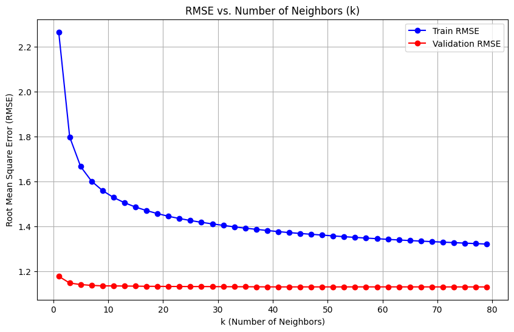

```
Testing item-based similarity...
Best k for Train RMSE: k=79, RMSE=1.298501466588672
Best k for Validation RMSE: k=33, RMSE=1.1298453574591476
```

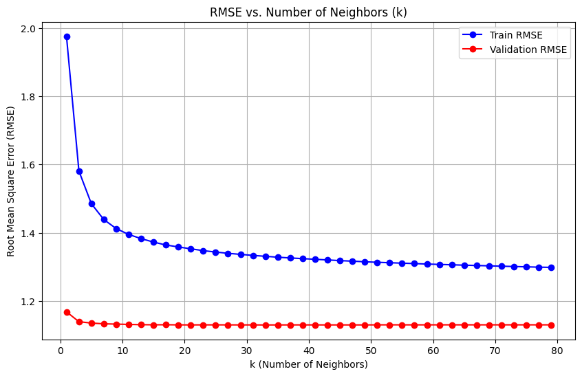

```python
# Compute the similarity matrices
user_similarity_matrix = similarity_matrix(sparse_matrix_train, between='users')
item_similarity_matrix = similarity_matrix(sparse_matrix_train, between='items')

# Convert sparse matrices to dense for prediction
dense_matrix_train = sparse_matrix_train.todense()
dense_matrix_val = sparse_matrix_val.todense()

# Test with user-based similarity
print("Testing user-based similarity...")
test_k_values(dense_matrix_train, dense_matrix_val, user_similarity_matrix, kind='user', max_k=80)

# Test with item-based similarity
print("Testing item-based similarity...")
test_k_values(dense_matrix_train, dense_matrix_val, item_similarity_matrix, kind='item', max_k=80)
```

```python
# Apply the splitting functions
sparse_matrix, user_categories, item_categories = create_rating_matrix(filtered_df, user_col='user_id', item_col='business_id', rating_col='stars_review')
sparse_matrix_train, sparse_matrix_val, sparse_matrix_test = split_rating_data(sparse_matrix, random_seed=42)

# Compute the user-user and item-item similarity matrices
user_similarity_matrix = similarity_matrix(sparse_matrix_train, between='users')
item_similarity_matrix = similarity_matrix(sparse_matrix_train, between='items')

# Convert sparse matrices to dense for prediction
dense_matrix_train = sparse_matrix_train.todense()
dense_matrix_val = sparse_matrix_val.todense()

# Get the top N recommendations for a given user
user_id = 'zLWaI3RP0IFCwMAERFRR0Q'
top_n_recommendations = get_top_n_recommendations(filtered_df, user_id, user_categories, item_categories, dense_matrix_train, user_similarity_matrix, kind='user', k=40, N=5)

print(top_n_recommendations)
```

```
Top Recommendations for Rowan:
              business_id   business_name  predicted_rating
0  2DTkzhmMpv5fIPKheePClA           Shaya          5.195958
1  gTC8IQ_i8zXytWSly3Ttvg  Cochon Butcher          5.169151
2  hfbZ97Te3T4jeWN6GgsGrQ      Willa Jean          5.116113
3  5xRmemqmR89BpGoOA25hqA        Dian Xin          4.985641
4  Vz2RN55rTJBGn43K1v84nA        Domenica          4.962725
```

**Improved Baseline Using Precomputed averages of dataset:**

```python
import numpy as np
import pandas as pd
import matplotlib.pyplot as plt
from sklearn.metrics import mean_squared_error

def calculate_rmse(pred, actual):
    """
    Calculate the root mean square error between predicted and actual ratings.
    """
    if isinstance(actual, (csr_matrix, csc_matrix)):
        actual = actual.todense()

    mask = actual != 0
    pred = np.asarray(pred)[mask].flatten()
    actual = np.asarray(actual)[mask].flatten()
    rmse = np.sqrt(mean_squared_error(actual, pred))
    return rmse

    return np.sqrt(mse)

def calculate_biases(filtered_df):
    user_bias = filtered_df.groupby('user_id', observed=True)['average_stars_user'].mean()
    item_bias = filtered_df.groupby('business_id', observed=True)['average_stars_business'].mean()
    return user_bias, item_bias

def predict_ratings_knn(ratings, similarity, filtered_df, kind='user', k=40, iterations=10):
    ratings = np.array(ratings)
    similarity = np.array(similarity)
    n_users, n_items = ratings.shape
    pred = np.zeros(ratings.shape)

    # Calculate the global average rating
    global_avg = np.mean(ratings[ratings > 0])

    # Get initial user and item biases
    user_bias, item_bias = calculate_biases(filtered_df)

    # Numpy arrays
    user_bias = np.array([user_bias.iloc[i] if i in user_bias.index else 0 for i in range(n_users)])
    item_bias = np.array([item_bias.iloc[j] if j in item_bias.index else 0 for j in range(n_items)])

    # Adjust biases iteratively
    for _ in range(iterations):
        for i in range(n_users):
            rated_items = ratings[i, :] > 0
            if np.any(rated_items):
                rated_items_indices = np.flatnonzero(rated_items)
                user_bias[i] = np.mean(ratings[i, rated_items_indices] - global_avg - item_bias[rated_items_indices])

        for j in range(n_items):
            rated_by_users = ratings[:, j] > 0
            if np.any(rated_by_users):
                rated_by_users_indices = np.flatnonzero(rated_by_users)
                item_bias[j] = np.mean(ratings[rated_by_users_indices, j] - global_avg - user_bias[rated_by_users_indices])

    if kind == 'user':
        for i in range(n_users):
            similarity[i, i] = -np.inf
            top_k_users = np.argsort(similarity[i])[:-k-1:-1]
            top_k_users = top_k_users[top_k_users < n_users]
            weights = similarity[i, top_k_users]

            if np.sum(np.abs(weights)) != 0:
                baseline = global_avg + user_bias[i]
                sub_ratings = ratings[top_k_users, :]
                normalized_sub_ratings = sub_ratings - user_bias[top_k_users].reshape(-1, 1)
                pred[i] = baseline + np.dot(weights, normalized_sub_ratings) / np.sum(np.abs(weights))

    else:
        for j in range(n_items):
            if j >= similarity.shape[0] or j >= similarity.shape[1]:
                continue
            similarity[j, j] = -np.inf
            top_k_items = np.argsort(similarity[:, j])[:-k-1:-1]
            top_k_items = top_k_items[top_k_items < n_items]
            weights = similarity[top_k_items, j]

            if np.sum(np.abs(weights)) != 0:
                baseline = global_avg + item_bias[j]
                sub_ratings = ratings[:, top_k_items]
                normalized_sub_ratings = sub_ratings - item_bias[top_k_items].reshape(1, -1)
                pred[:, j] = baseline + np.dot(normalized_sub_ratings, weights) / np.sum(np.abs(weights))
    return pred

def test_k_values(train_matrix, val_matrix, similarity_matrix, filtered_df, kind='item', max_k=40):
    """
    Test various k values for prediction and plot the RMSE for each k.
    """
    train_errors = []
    val_errors = []
    k_values = range(1, max_k + 1, 2)

    if isinstance(train_matrix, (csr_matrix, csc_matrix)):
        train_matrix = train_matrix.todense()
    if isinstance(val_matrix, (csr_matrix, csc_matrix)):
        val_matrix = val_matrix.todense()

    for k in k_values:
        preds_train = predict_ratings_knn(train_matrix, similarity_matrix, filtered_df, kind=kind, k=k)
        if preds_train.shape != train_matrix.shape:
            raise ValueError(f"Shape mismatch: {preds_train.shape} predictions vs {train_matrix.shape} train matrix.")
        rmse_train = calculate_rmse(preds_train, train_matrix)
        train_errors.append(rmse_train)

        preds_val = predict_ratings_knn(val_matrix, similarity_matrix, filtered_df, kind=kind, k=k)
        if preds_val.shape != val_matrix.shape:
            raise ValueError(f"Shape mismatch: {preds_val.shape} predictions vs {val_matrix.shape} val matrix.")
        rmse_val = calculate_rmse(preds_val, val_matrix)
        val_errors.append(rmse_val)

        print(f"k={k}: Train RMSE={rmse_train}, Validation RMSE={rmse_val}")

    best_k_train = k_values[np.argmin(train_errors)]
    best_rmse_train = min(train_errors)
    best_k_val = k_values[np.argmin(val_errors)]
    best_rmse_val = min(val_errors)

    print(f"Best k for Train RMSE: k={best_k_train}, RMSE={best_rmse_train}")
    print(f"Best k for Validation RMSE: k={best_k_val}, RMSE={best_rmse_val}")

    plt.figure(figsize=(10, 6))
    plt.plot(k_values, train_errors, marker='o', linestyle='-', color='b', label='Train RMSE')
    plt.plot(k_values, val_errors, marker='o', linestyle='-', color='r', label='Validation RMSE')
    plt.title('RMSE vs. Number of Neighbors (k)')
    plt.xlabel('k (Number of Neighbors)')
    plt.ylabel('Root Mean Square Error (RMSE)')
    plt.legend()
    plt.grid(True)
    plt.show()
```

```python
def get_user_rated_recommendations(df, user_id, user_categories, item_categories, ratings_matrix, similarity_matrix, filtered_df, kind='user', k=40, N=5):
    """
    Get the top N rated business predictions for a given user, including businesses the user has already rated.
    """
    # Get the index of the user in the ratings matrix
    user_idx = user_categories.get_loc(user_id)

    # Predict ratings for all users or items
    pred_ratings = predict_ratings_knn(ratings_matrix, similarity_matrix, filtered_df, kind=kind, k=k)

    # Get the predicted and actual ratings for the given user
    user_pred_ratings = pred_ratings[user_idx, :]
    user_actual_ratings = np.asarray(ratings_matrix[user_idx, :]).flatten()

    # Find indices where the user has rated businesses
    rated_indices = np.where(user_actual_ratings > 0)[0]

    # Get the predicted ratings for rated businesses
    rated_predictions = user_pred_ratings[rated_indices]
    actual_ratings = user_actual_ratings[rated_indices]

    # Get the indices of the top N recommendations based on predicted ratings
    top_n_indices = np.argsort(rated_predictions)[-N:][::-1]

    # Map back to business names
    top_n_business_names = [biznamefromid(df, item_categories[i]) for i in rated_indices[top_n_indices]]

    # Create a DataFrame to return
    top_n_recommendations = pd.DataFrame({
        'business_name': top_n_business_names,
        'actual_rating': actual_ratings[top_n_indices],
        'predicted_rating': rated_predictions[top_n_indices]
    })

    # Print the top recommendations for the user
    user_name = usernamefromid(df, user_id)
    print(f"Top Rated Recommendations for {user_name} (already rated by user):")

    return top_n_recommendations
```

```
Testing user-based similarity...
k=1: Train RMSE=2.3340583787353593, Validation RMSE=1.1275152071567331
k=3: Train RMSE=1.8620300338052984, Validation RMSE=0.9799404880162624
k=5: Train RMSE=1.7127085364006973, Validation RMSE=0.94226638936416
k=7: Train RMSE=1.6323548984335208, Validation RMSE=0.9267671318967731
k=9: Train RMSE=1.5805540035295484, Validation RMSE=0.9176256908832089
k=11: Train RMSE=1.5426069254505914, Validation RMSE=0.9136760065908137
k=13: Train RMSE=1.5129510430888073, Validation RMSE=0.9098968550776118
k=15: Train RMSE=1.4884102127948056, Validation RMSE=0.9074287490455212
k=17: Train RMSE=1.468974108485599, Validation RMSE=0.9050100570138712
k=19: Train RMSE=1.4520905219200335, Validation RMSE=0.9039179230275042
k=21: Train RMSE=1.4368993613426067, Validation RMSE=0.9021092973144254
k=23: Train RMSE=1.4247071839874157, Validation RMSE=0.9015930679235687
k=25: Train RMSE=1.4135199268679457, Validation RMSE=0.9002971252817051
k=27: Train RMSE=1.4037678216624674, Validation RMSE=0.8996506858257497
k=29: Train RMSE=1.3951310435241082, Validation RMSE=0.8988524856168475
k=31: Train RMSE=1.3868613513856578, Validation RMSE=0.8980828678252409
k=33: Train RMSE=1.3787761679103578, Validation RMSE=0.8976799913944481
k=35: Train RMSE=1.3717145650396725, Validation RMSE=0.8972608919684082
k=37: Train RMSE=1.36531191511775, Validation RMSE=0.89654870552753
k=39: Train RMSE=1.3587293724667255, Validation RMSE=0.8959868375047181
k=41: Train RMSE=1.3527344328065294, Validation RMSE=0.8956443088675345
k=43: Train RMSE=1.3473627920201148, Validation RMSE=0.8952164819990102
k=45: Train RMSE=1.3426530157403835, Validation RMSE=0.894809607203272
k=47: Train RMSE=1.3381437462969963, Validation RMSE=0.8943318760602413
k=49: Train RMSE=1.3337684297521781, Validation RMSE=0.8939719095501828
k=51: Train RMSE=1.3292654885130308, Validation RMSE=0.8935000309880936
k=53: Train RMSE=1.3249442865744494, Validation RMSE=0.8934389425620511
k=55: Train RMSE=1.3211758868622232, Validation RMSE=0.8930868146565081
k=57: Train RMSE=1.3175220877556642, Validation RMSE=0.8927284869056723
k=59: Train RMSE=1.3140016057251738, Validation RMSE=0.892464888893199
k=61: Train RMSE=1.3102338371345257, Validation RMSE=0.8922095772090674
k=63: Train RMSE=1.3068670597258696, Validation RMSE=0.8919049682581871
k=65: Train RMSE=1.3037968164894502, Validation RMSE=0.8918561112813613
k=67: Train RMSE=1.3008578858140665, Validation RMSE=0.891602841871
k=69: Train RMSE=1.2980257732720033, Validation RMSE=0.891534096677005
k=71: Train RMSE=1.295338633906791, Validation RMSE=0.8912884047134947
k=73: Train RMSE=1.292527497688426, Validation RMSE=0.8910708770921071
k=75: Train RMSE=1.2899139357966762, Validation RMSE=0.89084412107027
k=77: Train RMSE=1.2873326397276936, Validation RMSE=0.890627836612
k=79: Train RMSE=1.2849046377626316, Validation RMSE=0.8905481035754178
Best k for Train RMSE: k=79, RMSE=1.2849046377626316
Best k for Validation RMSE: k=79, RMSE=0.8905481035754178
```

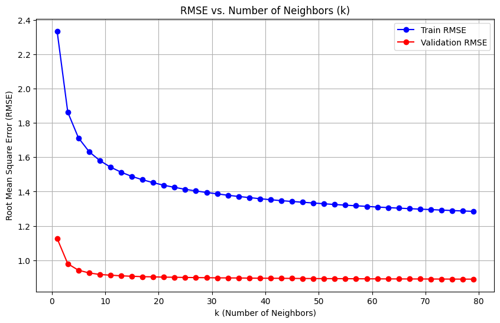

```
Testing item-based similarity...
k=1: Train RMSE=2.024542177651942, Validation RMSE=1.1556256580463153
k=3: Train RMSE=1.612026179288156, Validation RMSE=1.1124729558395117
k=5: Train RMSE=1.5098077525842217, Validation RMSE=1.1060162160511249
k=7: Train RMSE=1.4587422841283835, Validation RMSE=1.1012998743765179
k=9: Train RMSE=1.4277490873263776, Validation RMSE=1.09861129529977
k=11: Train RMSE=1.4095617048338616, Validation RMSE=1.0966398746646024
k=13: Train RMSE=1.3948067169900058, Validation RMSE=1.0946815358500768
k=15: Train RMSE=1.3836147709442965, Validation RMSE=1.0945835853530073
k=17: Train RMSE=1.3734326670526396, Validation RMSE=1.094309703420155
k=19: Train RMSE=1.3670232875852868, Validation RMSE=1.0934723912774666
k=21: Train RMSE=1.3602355003377626, Validation RMSE=1.093189129879251
k=23: Train RMSE=1.3537087711902136, Validation RMSE=1.0934311503165082
k=25: Train RMSE=1.3487533915255683, Validation RMSE=1.0933969460144424
k=27: Train RMSE=1.3445496754872253, Validation RMSE=1.0930714748824908
k=29: Train RMSE=1.3404892040052863, Validation RMSE=1.0928952516319688
k=31: Train RMSE=1.3369068909139088, Validation RMSE=1.0928641351006987
k=33: Train RMSE=1.333738491462594, Validation RMSE=1.092785649782191
k=35: Train RMSE=1.330556549464726, Validation RMSE=1.0926878217442904
k=37: Train RMSE=1.3278899533118025, Validation RMSE=1.0926876938969081
k=39: Train RMSE=1.3254159887756563, Validation RMSE=1.0927371557601793
k=41: Train RMSE=1.3229852591381783, Validation RMSE=1.092577359341895
k=43: Train RMSE=1.3207005279724666, Validation RMSE=1.0924946193112228
k=45: Train RMSE=1.318389655014223, Validation RMSE=1.0924970304941126
k=47: Train RMSE=1.3164182973491954, Validation RMSE=1.0924189045219805
k=49: Train RMSE=1.3143563976244452, Validation RMSE=1.0924909826218314
k=51: Train RMSE=1.3123535816310847, Validation RMSE=1.092455050683661
k=53: Train RMSE=1.3106011099771975, Validation RMSE=1.0925389598358108
k=55: Train RMSE=1.309116448228743, Validation RMSE=1.0923865784307485
k=57: Train RMSE=1.3076260679166007, Validation RMSE=1.0924527918456137
k=59: Train RMSE=1.306116618033625, Validation RMSE=1.092459299956993
k=61: Train RMSE=1.3047539708284577, Validation RMSE=1.0924037837127407
k=63: Train RMSE=1.3033196841812347, Validation RMSE=1.0922786628154624
k=65: Train RMSE=1.3019674236340162, Validation RMSE=1.0922112516682025
k=67: Train RMSE=1.3008102642645523, Validation RMSE=1.0920610165306734
k=69: Train RMSE=1.2997007398029892, Validation RMSE=1.0919112476365023
k=71: Train RMSE=1.2983813946089995, Validation RMSE=1.0919045449626659
k=73: Train RMSE=1.2972683064407138, Validation RMSE=1.0918832126468532
k=75: Train RMSE=1.29606921268741, Validation RMSE=1.0918513591356485
k=77: Train RMSE=1.294863307564832, Validation RMSE=1.091683769759804
k=79: Train RMSE=1.2939339501554805, Validation RMSE=1.0916498241513437
Best k for Train RMSE: k=79, RMSE=1.2939339501554805
Best k for Validation RMSE: k=79, RMSE=1.0916498241513437
```

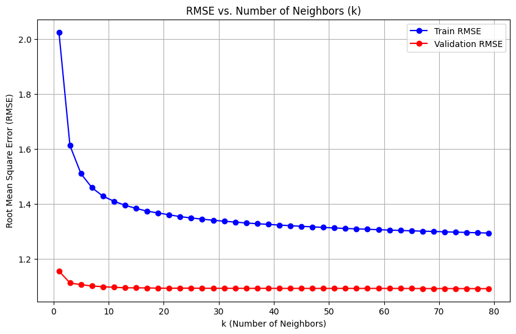

```python
# Compute the similarity matrices
user_similarity_matrix = similarity_matrix(sparse_matrix_train, between='users')
item_similarity_matrix = similarity_matrix(sparse_matrix_train, between='items')

# Convert sparse matrices to dense for prediction
dense_matrix_train = sparse_matrix_train.todense()
dense_matrix_val = sparse_matrix_val.todense()

# Test with user-based similarity
print("Testing user-based similarity...")
test_k_values(dense_matrix_train, dense_matrix_val, user_similarity_matrix, filtered_df, kind='user', max_k=80)

# Test with item-based similarity
print("Testing item-based similarity...")
test_k_values(dense_matrix_train, dense_matrix_val, item_similarity_matrix, filtered_df, kind='item', max_k=80)
```

## Tryin Different Similarity Calculations

```python
def to_dense(matrix):
    if isinstance(matrix, csr_matrix):
        return matrix.toarray()
    return np.array(matrix)  # Ensure it is a NumPy array
```

**Pearson**

```python
def pearson_similarity_matrix(train_matrix, between='users', min_co_ratings=1, similarity_threshold=0.01, regularization=100):
    '''
    Returns the Pearson correlation similarity between users or items with adjustments for sparse data.
    '''
    # Convert to dense format if sparse
    if isinstance(train_matrix, csr_matrix):
        train_matrix = train_matrix.toarray()

    # Prepare the matrix for similarity calculations based on 'between'
    if between == 'users':
        # Transpose to make users the rows for user-user similarity
        matrix = train_matrix
    else:
        # Use the matrix as is for item-item similarity
        matrix = train_matrix.T

    # Calculate the co-rating counts
    co_rating_counts = np.dot(matrix > 0, matrix.T > 0)

    # Compute means and differences from the means
    mean_rating = matrix.mean(axis=1)
    diff_matrix = matrix - mean_rating[:, np.newaxis]

    # Calculate Pearson correlation coefficient matrix with regularization
    similarity = np.dot(diff_matrix, diff_matrix.T) + regularization
    norm = np.sqrt(np.diag(similarity))
    similarity = similarity / norm[:, np.newaxis] / norm

    # Apply thresholding based on co-ratings and similarity strength
    similarity[co_rating_counts < min_co_ratings] = 0
    similarity[similarity < similarity_threshold] = 0

    return similarity
```

```python
print("User similarity matrix shape:", user_pearson_similarity_matrix.shape)
print("Item similarity matrix shape:", item_pearson_similarity_matrix.shape)
print("Train matrix shape:", dense_matrix_train.shape)
print("Validation matrix shape:", dense_matrix_val.shape)
```

```
User similarity matrix shape: (1926, 1926)
Item similarity matrix shape: (3978, 3978)
Train matrix shape: (3978, 1926)
Validation matrix shape: (3978, 1926)
```

```python
# Compute item-item Pearson similarity matrix from the training set
item_pearson_similarity_matrix = pearson_similarity_matrix(sparse_matrix_train, between='item')

# Compute user-user Pearson similarity matrix from the training set
user_pearson_similarity_matrix = pearson_similarity_matrix(sparse_matrix_train, between='users')
```

```
Testing user-based similarity...
k=1: Train RMSE=2.0343689338125523, Validation RMSE=1.304508156628447
k=3: Train RMSE=1.592232506893826, Validation RMSE=1.0804907115068858
k=5: Train RMSE=1.4684580949551138, Validation RMSE=1.0141953965142805
k=7: Train RMSE=1.4054132969455289, Validation RMSE=0.9837146780697478
k=9: Train RMSE=1.363706964557873, Validation RMSE=0.9670959731975329
k=11: Train RMSE=1.3353663227912653, Validation RMSE=0.9568880957043808
k=13: Train RMSE=1.3153963325148128, Validation RMSE=0.9490858639063631
k=15: Train RMSE=1.2983812880804209, Validation RMSE=0.942803231305488
k=17: Train RMSE=1.2839563605515674, Validation RMSE=0.9376818667429645
k=19: Train RMSE=1.272286569888237, Validation RMSE=0.9345129027574616
k=21: Train RMSE=1.2620240429407268, Validation RMSE=0.9309473560779932
k=23: Train RMSE=1.252800321082688, Validation RMSE=0.92815274778582
k=25: Train RMSE=1.2455253188201258, Validation RMSE=0.9261427121234375
k=27: Train RMSE=1.238665442490668, Validation RMSE=0.9240661566313778
k=29: Train RMSE=1.232669506000771, Validation RMSE=0.9223424594114197
k=31: Train RMSE=1.2271124203167765, Validation RMSE=0.9211955752634341
k=33: Train RMSE=1.2218378050283027, Validation RMSE=0.9198449861415198
k=35: Train RMSE=1.217330374089223, Validation RMSE=0.9185931384902205
k=37: Train RMSE=1.2128871972090332, Validation RMSE=0.9175422874552976
k=39: Train RMSE=1.208881137384171, Validation RMSE=0.9165936549315751
k=41: Train RMSE=1.205040362316428, Validation RMSE=0.9154988456453538
k=43: Train RMSE=1.2016644848912355, Validation RMSE=0.9146804855286155
k=45: Train RMSE=1.198557706491993, Validation RMSE=0.9137151349173385
k=47: Train RMSE=1.1953604035093852, Validation RMSE=0.9128187720561964
k=49: Train RMSE=1.1924259108373167, Validation RMSE=0.9120682992921568
k=51: Train RMSE=1.1897016563836023, Validation RMSE=0.9114521588412287
k=53: Train RMSE=1.1870656760823652, Validation RMSE=0.9106742129925658
k=55: Train RMSE=1.1848050795413057, Validation RMSE=0.9099532056179555
k=57: Train RMSE=1.1822906452680861, Validation RMSE=0.9095269456205437
k=59: Train RMSE=1.1804322057004968, Validation RMSE=0.9087864610633397
k=61: Train RMSE=1.178245084602258, Validation RMSE=0.9081437874009132
k=63: Train RMSE=1.1765030750976977, Validation RMSE=0.9076778462564956
k=65: Train RMSE=1.1750503674250552, Validation RMSE=0.9069919765364794
k=67: Train RMSE=1.1734426129624171, Validation RMSE=0.9064519119149637
k=69: Train RMSE=1.1719785722642642, Validation RMSE=0.9059457130277655
k=71: Train RMSE=1.1705178167284296, Validation RMSE=0.9056662941507758
k=73: Train RMSE=1.1690545401499912, Validation RMSE=0.9052281140795526
k=75: Train RMSE=1.1677002143894117, Validation RMSE=0.904904501641548
k=77: Train RMSE=1.1662722861116932, Validation RMSE=0.9045572591374944
k=79: Train RMSE=1.1649125257958781, Validation RMSE=0.9041461001264736
Best k for Train RMSE: k=79, RMSE=1.1649125257958781
Best k for Validation RMSE: k=79, RMSE=0.9041461001264736
```

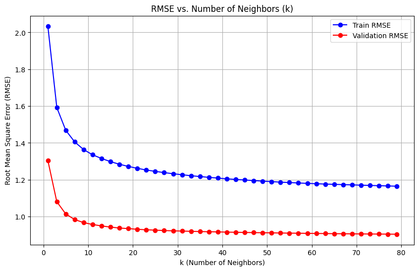

```
Testing item-based similarity...
k=1: Train RMSE=1.6220496487361356, Validation RMSE=1.1779214819485897
k=3: Train RMSE=1.371401990274923, Validation RMSE=1.1287985082982503
k=5: Train RMSE=1.3357436362701156, Validation RMSE=1.1214292857028216
k=7: Train RMSE=1.3280506228333733, Validation RMSE=1.1165080176902829
k=9: Train RMSE=1.3215515183063504, Validation RMSE=1.1129670065338522
k=11: Train RMSE=1.3191283867893255, Validation RMSE=1.1100754419258057
k=13: Train RMSE=1.3119457332564106, Validation RMSE=1.1077540556090553
k=15: Train RMSE=1.3067490000429691, Validation RMSE=1.1065993919789263
k=17: Train RMSE=1.3044663527044487, Validation RMSE=1.104394816124787
k=19: Train RMSE=1.3003013904813765, Validation RMSE=1.1032964624837045
k=21: Train RMSE=1.2969155517513864, Validation RMSE=1.1029083713141468
k=23: Train RMSE=1.2925670455944949, Validation RMSE=1.102580672877594
k=25: Train RMSE=1.290845833366056, Validation RMSE=1.101938098483214
k=27: Train RMSE=1.2877207451681134, Validation RMSE=1.1014781731731622
k=29: Train RMSE=1.2851712020744597, Validation RMSE=1.1011782728839477
k=31: Train RMSE=1.2814235029521368, Validation RMSE=1.1010864664355633
k=33: Train RMSE=1.278422751870424, Validation RMSE=1.1009166819786012
k=35: Train RMSE=1.2748868055450844, Validation RMSE=1.100702404553919
k=37: Train RMSE=1.2714431110669597, Validation RMSE=1.1006756173479222
k=39: Train RMSE=1.2683288124763359, Validation RMSE=1.1009142927530362
k=41: Train RMSE=1.2653770676728076, Validation RMSE=1.1008448760764582
k=43: Train RMSE=1.2627492345795817, Validation RMSE=1.100249451919166
k=45: Train RMSE=1.2596986872486697, Validation RMSE=1.1003533950233297
k=47: Train RMSE=1.2572865262319703, Validation RMSE=1.1000276524240398
k=49: Train RMSE=1.254545879298863, Validation RMSE=1.099791900032279
k=51: Train RMSE=1.252419354126581, Validation RMSE=1.099648462661164
k=53: Train RMSE=1.2499318723992836, Validation RMSE=1.099730788239545
k=55: Train RMSE=1.2472124219888032, Validation RMSE=1.0994513302915307
k=57: Train RMSE=1.2448328982138208, Validation RMSE=1.0997507096941228
k=59: Train RMSE=1.2427509125958052, Validation RMSE=1.0996514992973758
k=61: Train RMSE=1.2402702872609441, Validation RMSE=1.099290145292876
k=63: Train RMSE=1.2382342746626733, Validation RMSE=1.0991993315627209
k=65: Train RMSE=1.2360098383617562, Validation RMSE=1.0991008629631291
k=67: Train RMSE=1.2340565145685123, Validation RMSE=1.0990396649604872
k=69: Train RMSE=1.2322935607643446, Validation RMSE=1.098971063837134
k=71: Train RMSE=1.230411834215132, Validation RMSE=1.098956843030781
k=73: Train RMSE=1.228724711618221, Validation RMSE=1.0989982537924816
k=75: Train RMSE=1.227044371300731, Validation RMSE=1.0989699057269395
k=77: Train RMSE=1.2255401029139428, Validation RMSE=1.0988928308243715
k=79: Train RMSE=1.2241695112630604, Validation RMSE=1.0988031433213465
Best k for Train RMSE: k=79, RMSE=1.2241695112630604
Best k for Validation RMSE: k=79, RMSE=1.0988031433213465
```

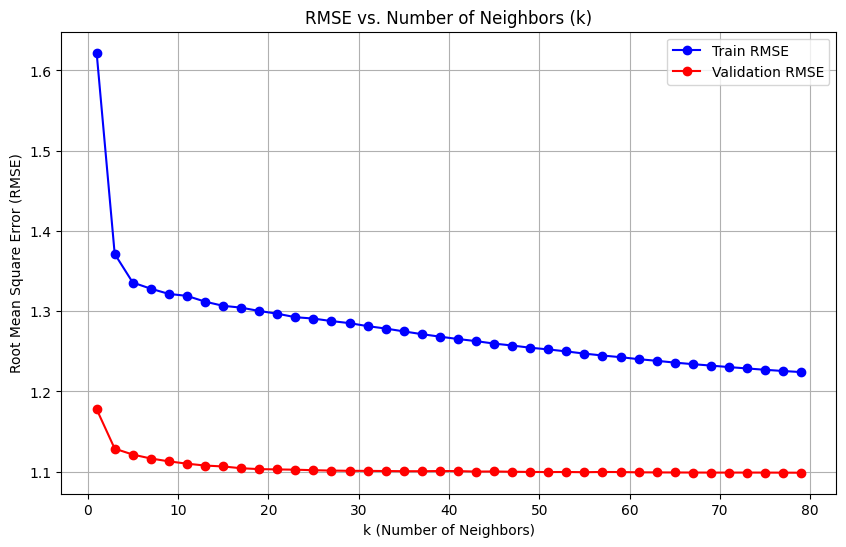

```python
# Compute item-item Pearson similarity matrix from the training set
item_pearson_similarity_matrix = pearson_similarity_matrix(sparse_matrix_train, between='item')

# Compute user-user Pearson similarity matrix from the training set
user_pearson_similarity_matrix = pearson_similarity_matrix(sparse_matrix_train, between='users')

# Convert sparse matrices to dense for prediction
dense_matrix_train = to_dense(sparse_matrix_train)
dense_matrix_val = to_dense(sparse_matrix_val)

# Test with user-based similarity
print("Testing user-based similarity...")
test_k_values(dense_matrix_train, dense_matrix_val, user_pearson_similarity_matrix, filtered_df, kind='user', max_k=80)

# Test with item-based similarity
print("Testing item-based similarity...")
test_k_values(dense_matrix_train, dense_matrix_val, item_pearson_similarity_matrix, filtered_df, kind='item', max_k=80)
```

```python
# Apply the splitting functions
sparse_matrix, user_categories, item_categories = create_rating_matrix(filtered_df, user_col='user_id', item_col='business_id', rating_col='stars_review')
sparse_matrix_train, sparse_matrix_val, sparse_matrix_test = split_rating_data(sparse_matrix, random_seed=42)

# Compute item-item Pearson similarity matrix from the training set
item_pearson_similarity_matrix = pearson_similarity_matrix(sparse_matrix_train, between='item')

# Compute user-user Pearson similarity matrix from the training set
user_pearson_similarity_matrix = pearson_similarity_matrix(sparse_matrix_train, between='users')

# Convert sparse matrices to dense for prediction
dense_matrix_train = sparse_matrix_train.todense()
dense_matrix_val = sparse_matrix_val.todense()

# Get the top N recommendations for a given user
user_id = 'zLWaI3RP0IFCwMAERFRR0Q'
top_n_recommendations = get_top_n_recommendations(filtered_df, user_id, user_categories, item_categories, dense_matrix_train, user_pearson_similarity_matrix, filtered_df, kind='user', k=40, N=5)

print(top_n_recommendations)
```

```
Top Recommendations for Rowan:
              business_id            business_name  predicted_rating
0  zI0OdjkdQqD7az8aM6ppdg                 Cho Thai          4.700439
1  hfbZ97Te3T4jeWN6GgsGrQ               Willa Jean          4.410056
2  5xRmemqmR89BpGoOA25hqA                 Dian Xin          4.374607
3  2DTkzhmMpv5fIPKheePClA                    Shaya          4.366256
4  TcNZXteosegb1RO4O5hREw  Parkway Bakery & Tavern          4.346708
```

```python
def adjusted_cosine_similarity_matrix(train_matrix, between='users'):
    '''Returns the adjusted cosine similarity between users or items'''
    if between == 'users':
        mean_user_rating = np.array(train_matrix.mean(axis=1)).flatten()
        diff_matrix = train_matrix - mean_user_rating[:, np.newaxis]
        similarity = diff_matrix @ diff_matrix.T
    else:
        mean_item_rating = np.array(train_matrix.mean(axis=0)).flatten()
        diff_matrix = train_matrix - mean_item_rating
        similarity = diff_matrix.T @ diff_matrix

    norm_array = np.sqrt(np.diag(similarity)) + 1e-8  # Adding small constant to avoid division by zero
    similarity = similarity / norm_array / norm_array.reshape(-1, 1)
    similarity = np.nan_to_num(similarity)  # Convert NaNs to zero

    return similarity
```

```python
# Compute item-item adjusted cosine similarity matrix from the training set
item_adjusted_cosine_similarity_matrix = adjusted_cosine_similarity_matrix(sparse_matrix_train, between='item')

# Compute user-user adjusted cosine similarity matrix from the training set
user_adjusted_cosine_similarity_matrix = adjusted_cosine_similarity_matrix(sparse_matrix_train, between='users')
```

```
Testing user-based similarity...
k=1: Train RMSE=2.1956837122917507, Validation RMSE=1.1312109076772043
k=3: Train RMSE=1.706629502001275, Validation RMSE=0.9779871791700613
k=5: Train RMSE=1.5763158112069826, Validation RMSE=0.9425783207385826
k=7: Train RMSE=1.5076412204831473, Validation RMSE=0.9273020688919974
k=9: Train RMSE=1.4671273558237121, Validation RMSE=0.9174551823490925
k=11: Train RMSE=1.4392364250496752, Validation RMSE=0.9132159669127818
k=13: Train RMSE=1.4172057440779615, Validation RMSE=0.9100572443924811
k=15: Train RMSE=1.4003084925595324, Validation RMSE=0.9077100579643945
k=17: Train RMSE=1.3841500503856876, Validation RMSE=0.9048970775876671
k=19: Train RMSE=1.3707573093259415, Validation RMSE=0.9038650929921506
k=21: Train RMSE=1.359542300483287, Validation RMSE=0.9022899794277361
k=23: Train RMSE=1.3499383443595336, Validation RMSE=0.9019822448667741
k=25: Train RMSE=1.3415087306307945, Validation RMSE=0.9007508135196955
k=27: Train RMSE=1.3330969412644231, Validation RMSE=0.9000711132807963
k=29: Train RMSE=1.3265274221845293, Validation RMSE=0.8988434804029632
k=31: Train RMSE=1.3198907023735142, Validation RMSE=0.8983159186267208
k=33: Train RMSE=1.3140577484090221, Validation RMSE=0.8976566049086094
k=35: Train RMSE=1.3085887848142528, Validation RMSE=0.8970566334049813
k=37: Train RMSE=1.3036582952803486, Validation RMSE=0.8963726349646259
k=39: Train RMSE=1.2994069231087144, Validation RMSE=0.8957769232400704
k=41: Train RMSE=1.2949757436616631, Validation RMSE=0.8954197631273677
k=43: Train RMSE=1.2909446122043697, Validation RMSE=0.8951266549387428
k=45: Train RMSE=1.286891650025864, Validation RMSE=0.894569357823452
k=47: Train RMSE=1.2836039455601338, Validation RMSE=0.8940433290492239
k=49: Train RMSE=1.2801580072669574, Validation RMSE=0.8937966467408297
k=51: Train RMSE=1.276545873416962, Validation RMSE=0.8936651525680107
k=53: Train RMSE=1.2734595569335816, Validation RMSE=0.8933764701356869
k=55: Train RMSE=1.2705118479501194, Validation RMSE=0.8929684708923086
k=57: Train RMSE=1.267471131248407, Validation RMSE=0.8926728006232414
k=59: Train RMSE=1.264757935983834, Validation RMSE=0.8924487440472317
k=61: Train RMSE=1.2620176677769512, Validation RMSE=0.8922319614115263
k=63: Train RMSE=1.2595609947044608, Validation RMSE=0.8921467272545269
k=65: Train RMSE=1.2569507230488008, Validation RMSE=0.8918596210065584
k=67: Train RMSE=1.2547151163071533, Validation RMSE=0.8916118065173803
k=69: Train RMSE=1.2526054512114337, Validation RMSE=0.8914643993979757
k=71: Train RMSE=1.2504114946253808, Validation RMSE=0.8912362412262455
k=73: Train RMSE=1.248339033549176, Validation RMSE=0.8910481111564684
k=75: Train RMSE=1.246367745736331, Validation RMSE=0.8908562625602713
k=77: Train RMSE=1.2441832390177352, Validation RMSE=0.8906798779621117
k=79: Train RMSE=1.2423201787025502, Validation RMSE=0.8905034447595523
Best k for Train RMSE: k=79, RMSE=1.2423201787025502
Best k for Validation RMSE: k=79, RMSE=0.8905034447595523
```

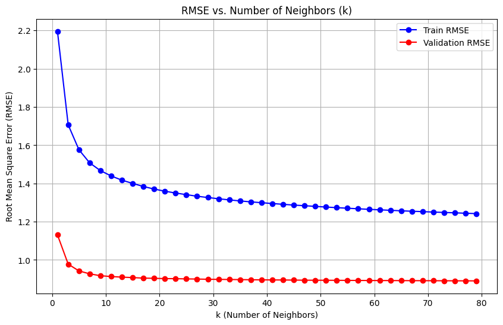

```
Testing item-based similarity...
k=1: Train RMSE=1.8847610172909683, Validation RMSE=1.154380049620518
k=3: Train RMSE=1.511459640606497, Validation RMSE=1.1156997630374736
k=5: Train RMSE=1.419593740896175, Validation RMSE=1.1090104675711467
k=7: Train RMSE=1.375746958773045, Validation RMSE=1.1044183088153243
k=9: Train RMSE=1.3529461489053072, Validation RMSE=1.1017253175273265
k=11: Train RMSE=1.3367280573352833, Validation RMSE=1.1002152302186177
k=13: Train RMSE=1.324822976993862, Validation RMSE=1.0995318555426588
k=15: Train RMSE=1.3166285517478693, Validation RMSE=1.0990231798847072
k=17: Train RMSE=1.309548388169135, Validation RMSE=1.0989855226369636
k=19: Train RMSE=1.3036688379433585, Validation RMSE=1.0986548855098002
k=21: Train RMSE=1.2991993480924726, Validation RMSE=1.098701779768074
k=23: Train RMSE=1.2942777756188564, Validation RMSE=1.0991216131773065
k=25: Train RMSE=1.290646902024885, Validation RMSE=1.098471086962698
k=27: Train RMSE=1.2873314355741228, Validation RMSE=1.0983801623562834
k=29: Train RMSE=1.2844483697806957, Validation RMSE=1.0981313848176395
k=31: Train RMSE=1.282036486841784, Validation RMSE=1.0981241262749168
k=33: Train RMSE=1.279739585300109, Validation RMSE=1.0978378838037086
k=35: Train RMSE=1.2774813318473934, Validation RMSE=1.0979199668555217
k=37: Train RMSE=1.2755081646061663, Validation RMSE=1.0978636380939797
k=39: Train RMSE=1.2738318461299996, Validation RMSE=1.0978871855570722
k=41: Train RMSE=1.2724180773610243, Validation RMSE=1.0978444255269575
k=43: Train RMSE=1.271057348827212, Validation RMSE=1.0979019197262743
k=45: Train RMSE=1.2694677906945813, Validation RMSE=1.0977430501388585
k=47: Train RMSE=1.2680831233752587, Validation RMSE=1.097507882762967
k=49: Train RMSE=1.2666502426743356, Validation RMSE=1.0974790845308846
k=51: Train RMSE=1.2652260922796743, Validation RMSE=1.0973150798435842
k=53: Train RMSE=1.2639687813675284, Validation RMSE=1.0971970152792787
k=55: Train RMSE=1.2629703472093192, Validation RMSE=1.0970593163342404
k=57: Train RMSE=1.262135985748708, Validation RMSE=1.0971706932653962
k=59: Train RMSE=1.2612158045938753, Validation RMSE=1.097169645771301
k=61: Train RMSE=1.2604665000090856, Validation RMSE=1.0970821376079403
k=63: Train RMSE=1.259599731016531, Validation RMSE=1.0972924448432548
k=65: Train RMSE=1.2586061428437783, Validation RMSE=1.0972485177312037
k=67: Train RMSE=1.2577904852212198, Validation RMSE=1.0970793815169195
k=69: Train RMSE=1.2570197375428345, Validation RMSE=1.0969342517255483
k=71: Train RMSE=1.2561368235553572, Validation RMSE=1.0969204479525037
k=73: Train RMSE=1.2555148358917239, Validation RMSE=1.096761822423318
k=75: Train RMSE=1.2549175715021417, Validation RMSE=1.0967095313681332
k=77: Train RMSE=1.2543845580041844, Validation RMSE=1.0967107730170291
k=79: Train RMSE=1.2537201218251823, Validation RMSE=1.096610576364337
Best k for Train RMSE: k=79, RMSE=1.2537201218251823
Best k for Validation RMSE: k=79, RMSE=1.096610576364337
```

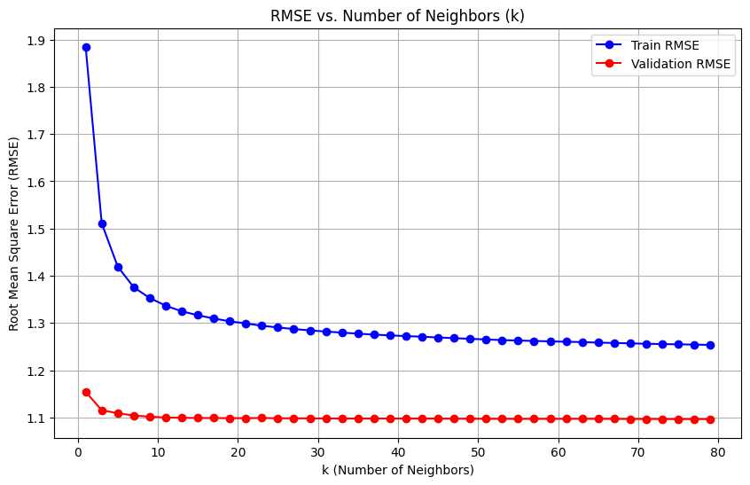

```python
# Compute item-item adjusted cosine similarity matrix from the training set
item_adjusted_cosine_similarity_matrix = adjusted_cosine_similarity_matrix(sparse_matrix_train, between='item')

# Compute user-user adjusted cosine similarity matrix from the training set
user_adjusted_cosine_similarity_matrix = adjusted_cosine_similarity_matrix(sparse_matrix_train, between='users')

# Convert sparse matrices to dense for prediction
dense_matrix_train = sparse_matrix_train.todense()
dense_matrix_val = sparse_matrix_val.todense()

# Test with user-based similarity
print("Testing user-based similarity...")
test_k_values(dense_matrix_train, dense_matrix_val, user_adjusted_cosine_similarity_matrix, filtered_df, kind='user', max_k=80)

# Test with item-based similarity
print("Testing item-based similarity...")
test_k_values(dense_matrix_train, dense_matrix_val, item_adjusted_cosine_similarity_matrix, filtered_df, kind='item', max_k=80)
```

```python
def jaccard_similarity_matrix(train_matrix, between='users'):
    '''Returns the Jaccard similarity between users or items'''
    train_matrix_binary = train_matrix > 0  # Convert to binary matrix

    if between == 'users':
        intersection = train_matrix_binary @ train_matrix_binary.T
        union = np.add.outer(train_matrix_binary.sum(axis=1).A1, train_matrix_binary.sum(axis=1).A1) - intersection
    else:
        intersection = train_matrix_binary.T @ train_matrix_binary
        union = np.add.outer(train_matrix_binary.sum(axis=0).A1, train_matrix_binary.sum(axis=0).A1) - intersection

    similarity = intersection / union
    similarity = similarity.todense()  # Convert to dense matrix for further processing
    np.fill_diagonal(similarity, 1)  # Ensure diagonal elements are 1 for self-similarity
    return np.array(similarity)
```

```python
def to_dense(matrix):
    if isinstance(matrix, csr_matrix):
        return matrix.toarray()
    return np.array(matrix)  # Ensure it is a NumPy array
```

```python
# Compute item-item Jaccard similarity matrix from the training set
item_jaccard_similarity_matrix = jaccard_similarity_matrix(sparse_matrix_train, between='item')

# Compute user-user Jaccard similarity matrix from the training set
user_jaccard_similarity_matrix = jaccard_similarity_matrix(sparse_matrix_train, between='users')
```

```
Testing user-based similarity...
k=1: Train RMSE=1.8975683489490938, Validation RMSE=1.459371321931191
k=3: Train RMSE=1.3469537675238905, Validation RMSE=1.0392587762656496
k=5: Train RMSE=1.2505934626134205, Validation RMSE=0.9705229683377458
k=7: Train RMSE=1.2112694617228132, Validation RMSE=0.9445825306022045
k=9: Train RMSE=1.191439024221628, Validation RMSE=0.9286791840108705
k=11: Train RMSE=1.178337020833019, Validation RMSE=0.9184560826743396
k=13: Train RMSE=1.1699977224119253, Validation RMSE=0.9123752088024157
k=15: Train RMSE=1.1636231206561427, Validation RMSE=0.90847432022787
k=17: Train RMSE=1.1584064746668772, Validation RMSE=0.9060468062889664
k=19: Train RMSE=1.154654636135912, Validation RMSE=0.9033465392975674
k=21: Train RMSE=1.1517011307375702, Validation RMSE=0.9017971353615546
k=23: Train RMSE=1.1485843646583187, Validation RMSE=0.9002856894857711
k=25: Train RMSE=1.1466314967482782, Validation RMSE=0.8984173363368451
k=27: Train RMSE=1.1446975562768222, Validation RMSE=0.8978529452023685
k=29: Train RMSE=1.143255190907537, Validation RMSE=0.8966310410620913
k=31: Train RMSE=1.1418095531744656, Validation RMSE=0.8957418679587792
k=33: Train RMSE=1.1405251112902537, Validation RMSE=0.8953149106331636
k=35: Train RMSE=1.1397398850602127, Validation RMSE=0.8945840343725185
k=37: Train RMSE=1.1388395988996565, Validation RMSE=0.894330193070528
k=39: Train RMSE=1.138190007997876, Validation RMSE=0.8935312100855163
k=41: Train RMSE=1.1374489094551123, Validation RMSE=0.8928948699765228
k=43: Train RMSE=1.1367675370344532, Validation RMSE=0.8928450277808966
k=45: Train RMSE=1.1361953587973237, Validation RMSE=0.8921467634546085
k=47: Train RMSE=1.1356309000948166, Validation RMSE=0.8916663399099541
k=49: Train RMSE=1.1351113393083965, Validation RMSE=0.8911529441651183
k=51: Train RMSE=1.1346197333950578, Validation RMSE=0.8908509991219214
k=53: Train RMSE=1.1341729845544535, Validation RMSE=0.8905947206046103
k=55: Train RMSE=1.1336871432645381, Validation RMSE=0.8903599038737396
k=57: Train RMSE=1.133378163758909, Validation RMSE=0.8902428268550411
k=59: Train RMSE=1.133004602728846, Validation RMSE=0.8902629054665843
k=61: Train RMSE=1.1325587961383332, Validation RMSE=0.8899699010150045
k=63: Train RMSE=1.1322201855723324, Validation RMSE=0.8896863446719387
k=65: Train RMSE=1.1321615761217743, Validation RMSE=0.889391089694425
k=67: Train RMSE=1.1319868613628536, Validation RMSE=0.8893269024756217
k=69: Train RMSE=1.1317162141873942, Validation RMSE=0.88919938033419
k=71: Train RMSE=1.1315436217800807, Validation RMSE=0.889014737238543
k=73: Train RMSE=1.1313092445819424, Validation RMSE=0.8889426915221746
k=75: Train RMSE=1.1312634974594564, Validation RMSE=0.8887923602384217
k=77: Train RMSE=1.1312002234667324, Validation RMSE=0.8886791313718089
k=79: Train RMSE=1.130949655889266, Validation RMSE=0.8885589212108006
Best k for Train RMSE: k=79, RMSE=1.130949655889266
Best k for Validation RMSE: k=79, RMSE=0.8885589212108006
```

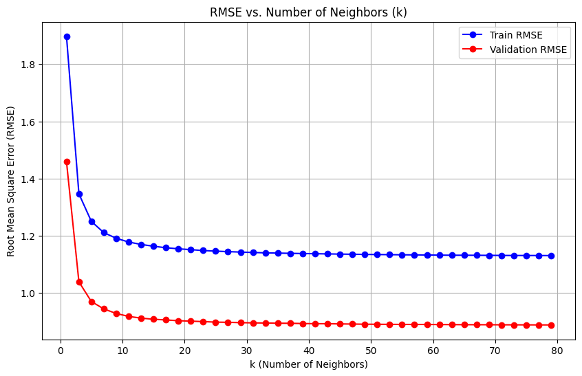

```
Testing item-based similarity...
k=1: Train RMSE=1.395771841373307, Validation RMSE=1.1490587970318096
k=3: Train RMSE=1.2384260191064866, Validation RMSE=1.11523536677881
k=5: Train RMSE=1.2059444061769835, Validation RMSE=1.1079526610773045
k=7: Train RMSE=1.1908517384999846, Validation RMSE=1.107143265280513
k=9: Train RMSE=1.1818521265872413, Validation RMSE=1.1035578341224235
k=11: Train RMSE=1.1778047676919488, Validation RMSE=1.1006560921447317
k=13: Train RMSE=1.1754694933743677, Validation RMSE=1.0979338104362935
k=15: Train RMSE=1.1754235456133224, Validation RMSE=1.0969622207265917
k=17: Train RMSE=1.174614617014981, Validation RMSE=1.096649995450921
k=19: Train RMSE=1.1742481875359116, Validation RMSE=1.0967265942149735
k=21: Train RMSE=1.1747512129953595, Validation RMSE=1.0964410980144745
k=23: Train RMSE=1.1745645727858305, Validation RMSE=1.0969961412653946
k=25: Train RMSE=1.1738784661927022, Validation RMSE=1.0971547777842898
k=27: Train RMSE=1.1730844129110276, Validation RMSE=1.0974902173363592
k=29: Train RMSE=1.1725671995752323, Validation RMSE=1.0972548368618413
k=31: Train RMSE=1.1718238201026385, Validation RMSE=1.0972270248517497
k=33: Train RMSE=1.1712034731768362, Validation RMSE=1.097091217169658
k=35: Train RMSE=1.1711395307054073, Validation RMSE=1.0971915908024386
k=37: Train RMSE=1.1708414361271073, Validation RMSE=1.096960320859073
k=39: Train RMSE=1.170643431318205, Validation RMSE=1.0967094937645008
k=41: Train RMSE=1.1701998354285248, Validation RMSE=1.0963186299567176
k=43: Train RMSE=1.1698371051396288, Validation RMSE=1.096374441616107
k=45: Train RMSE=1.1692864001628518, Validation RMSE=1.0966524130169768
k=47: Train RMSE=1.1689065414425015, Validation RMSE=1.0965740735107095
k=49: Train RMSE=1.1687311432206213, Validation RMSE=1.0967741077142836
k=51: Train RMSE=1.1683956867505811, Validation RMSE=1.0966549637871585
k=53: Train RMSE=1.1679000867296516, Validation RMSE=1.0967613279117499
k=55: Train RMSE=1.1672829664861677, Validation RMSE=1.0965679328375995
k=57: Train RMSE=1.1668263244407546, Validation RMSE=1.0960432142299983
k=59: Train RMSE=1.1662509120217588, Validation RMSE=1.0960136416653663
k=61: Train RMSE=1.1657840490424596, Validation RMSE=1.0958285874679146
k=63: Train RMSE=1.1653251388595678, Validation RMSE=1.0959342762887911
k=65: Train RMSE=1.1649823921511462, Validation RMSE=1.0959442279293974
k=67: Train RMSE=1.1645899205966368, Validation RMSE=1.0958197818786242
k=69: Train RMSE=1.1641504921162718, Validation RMSE=1.0959212419817967
k=71: Train RMSE=1.1639143156211178, Validation RMSE=1.0959843193760406
k=73: Train RMSE=1.1636624188511595, Validation RMSE=1.095830282078758
k=75: Train RMSE=1.1632300698802849, Validation RMSE=1.0957555547649036
k=77: Train RMSE=1.162955300036584, Validation RMSE=1.095459707896517
k=79: Train RMSE=1.1627944573371338, Validation RMSE=1.0952116125723426
Best k for Train RMSE: k=79, RMSE=1.1627944573371338
Best k for Validation RMSE: k=79, RMSE=1.0952116125723426
```

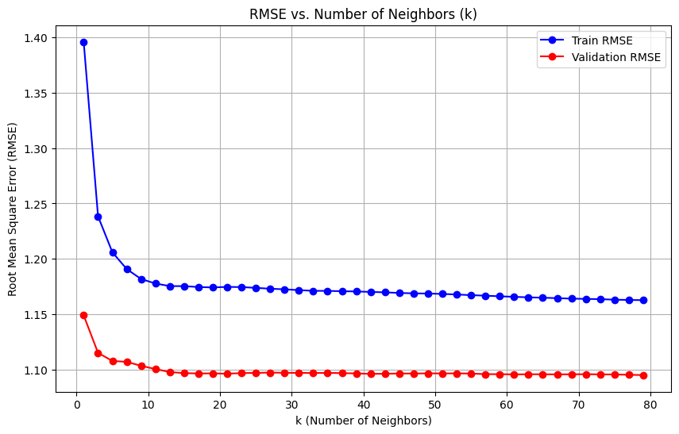

```python
# Compute item-item Jaccard similarity matrix from the training set
item_jaccard_similarity_matrix = jaccard_similarity_matrix(sparse_matrix_train, between='item')

# Compute user-user Jaccard similarity matrix from the training set
user_jaccard_similarity_matrix = jaccard_similarity_matrix(sparse_matrix_train, between='users')

# Convert sparse matrices to dense for prediction
dense_matrix_train = to_dense(sparse_matrix_train)
dense_matrix_val = to_dense(sparse_matrix_val)

# Test with user-based similarity
print("Testing user-based similarity...")
test_k_values(dense_matrix_train, dense_matrix_val, user_jaccard_similarity_matrix, filtered_df, kind='user', max_k=80)

# Test with item-based similarity
print("Testing item-based similarity...")
test_k_values(dense_matrix_train, dense_matrix_val, item_jaccard_similarity_matrix, filtered_df, kind='item', max_k=80)
```

```python
# Apply the splitting functions
sparse_matrix, user_categories, item_categories = create_rating_matrix(filtered_df, user_col='user_id', item_col='business_id', rating_col='stars_review')
sparse_matrix_train, sparse_matrix_val, sparse_matrix_test = split_rating_data(sparse_matrix, random_seed=42)

# Compute user-user Jaccard similarity matrix from the training set
user_jaccard_similarity_matrix = jaccard_similarity_matrix(sparse_matrix_train, between='users')

# Convert sparse matrices to dense for prediction
dense_matrix_train = sparse_matrix_train.todense()

# Get the top N recommendations for a given user
user_id = 'zLWaI3RP0IFCwMAERFRR0Q'
top_n_recommendations = get_top_n_recommendations(filtered_df, user_id, user_categories, item_categories, dense_matrix_train, user_jaccard_similarity_matrix, filtered_df, kind='user', k=20, N=10)

print(top_n_recommendations)
```

```
Top Recommendations for Rowan:
              business_id                 business_name  predicted_rating
0  qb28j-FNX1_6xm7u372TZA                    Gumbo Shop          4.663163
1  ac1AeYqs8Z4_e2X5M3if2A                  Oceana Grill          4.617421
2  Y2Pfil51rNvTd_lFHwzb_g  Cafe Beignet on Royal Street          4.514109
3  Et2yOijYQbWyR-mE0-z40w                 Tsunami Sushi          4.468368
4  gzMlFR9ViVCr_HUYPgqqVg                       Sylvain          4.464425
5  _SjdrpSZdiXVSwaJR5T9jw                        Squeal          4.371365
6  _ab50qdWOk0DdB6XOrBitw             Acme Oyster House          4.365056
7  EagkHaaC-kUozD3MPzbRIw                       Stanley          4.315371
8  FIUCEBg9hqVA-ZScn7N2IA       Tavolino Pizza & Lounge          4.219945
9  iC9Gis3-VspIr8Ox3e2beA         Chophouse New Orleans          4.219945
```

```python
# Apply the splitting functions
sparse_matrix, user_categories, item_categories = create_rating_matrix(filtered_df, user_col='user_id', item_col='business_id', rating_col='stars_review')
sparse_matrix_train, sparse_matrix_val, sparse_matrix_test = split_rating_data(sparse_matrix, random_seed=42)

# Compute user-user Jaccard similarity matrix from the training set
user_jaccard_similarity_matrix = jaccard_similarity_matrix(sparse_matrix_train, between='users')

# Convert sparse matrices to dense for prediction
dense_matrix_train = sparse_matrix_train.todense()

# Get the top N recommendations for a given user
user_id = 'zLWaI3RP0IFCwMAERFRR0Q'
top_n_recommendations = get_user_rated_recommendations(filtered_df, user_id, user_categories, item_categories, dense_matrix_train, user_jaccard_similarity_matrix, filtered_df, kind='user', k=20, N=10)

print(top_n_recommendations)
```

```
Top Rated Recommendations for Rowan (already rated by user):
                business_name  actual_rating  predicted_rating
0          Commander's Palace            5.0          5.412374
1   Surrey's Café & Juice Bar            4.0          4.464425
2                Blue Oak BBQ            5.0          4.421838
3  Lula Restaurant Distillery            5.0          4.368210
4     Stein's Market and Deli            5.0          4.320891
5                 Maïs Arepas            5.0          4.219945
6                 Pagoda Cafe            5.0          4.216002
7         Turkey and the Wolf            5.0          4.216002
8                      Lola's            5.0          4.216002
9         Baru Bistro & Tapas            4.0          4.166317
```

```python
top_n_recommendations
```

|  | business_id | business_name | predicted_rating | actual_rating |
| --- | --- | --- | --- | --- |
| 0 | _C7QiQQc47AOEv4PE3Kong | Commander's Palace | 5.412374 | 5.0 |
| 1 | vN6v8m4DO45Z4pp8yxxF_w | Surrey's Café & Juice Bar | 4.464425 | 4.0 |
| 2 | Meww6RIE4cFL_kG0aRlbAA | Blue Oak BBQ | 4.421838 | 5.0 |
| 3 | NHdE_ObFj7OjQBB3jjqBNQ | Lula Restaurant Distillery | 4.368210 | 5.0 |
| 4 | yL9j5ASNic_DaDKf9lwMhw | Stein's Market and Deli | 4.320891 | 5.0 |
| 5 | SBtjW_pKw3XaOKtKAavWZg | Maïs Arepas | 4.219945 | 5.0 |
| 6 | NgEy0AX40Yg4Bpon61wbEg | Pagoda Cafe | 4.216002 | 5.0 |
| 7 | UbFkHiEt9S-0mUL3RQ5Ghg | Turkey and the Wolf | 4.216002 | 5.0 |
| 8 | wYdlP6g2y6gK_RmLrPhsGA | Lola's | 4.216002 | 5.0 |
| 9 | L_P-FSan8ln6Kiybel7Yrw | Baru Bistro & Tapas | 4.166317 | 4.0 |

```python
# Create a dictionary with k-values and RMSEs for each similarity metric
data = {
    'k': range(1, 80, 2),
    'Adjusted Cosine': [
        1.1312, 0.9780, 0.9426, 0.9273, 0.9175, 0.9132, 0.9101, 0.9077,
        0.9049, 0.9039, 0.9023, 0.9020, 0.9008, 0.9001, 0.8988, 0.8983,
        0.8977, 0.8971, 0.8964, 0.8958, 0.8954, 0.8951, 0.8946, 0.8940,
        0.8938, 0.8937, 0.8934, 0.8931, 0.8929, 0.8925, 0.8925, 0.8922,
        0.8921, 0.8920, 0.8919, 0.8919, 0.8919, 0.8918, 0.8918, 0.8918
    ],
    'Pearson': [
        1.3045, 1.0805, 1.0142, 0.9837, 0.9671, 0.9569, 0.9491, 0.9428,
        0.9377, 0.9345, 0.9309, 0.9282, 0.9261, 0.9241, 0.9223, 0.9212,
        0.9198, 0.9186, 0.9175, 0.9166, 0.9155, 0.9147, 0.9137, 0.9128,
        0.9121, 0.9115, 0.9107, 0.9100, 0.9095, 0.9090, 0.9088, 0.9081,
        0.9077, 0.9070, 0.9069, 0.9065, 0.9065, 0.9060, 0.9059, 0.9057
    ],
    'Jaccard': [
        1.4594, 1.0393, 0.9705, 0.9446, 0.9287, 0.9185, 0.9124, 0.9085,
        0.9060, 0.9033, 0.9018, 0.9003, 0.8984, 0.8979, 0.8966, 0.8957,
        0.8953, 0.8946, 0.8943, 0.8935, 0.8929, 0.8928, 0.8921, 0.8917,
        0.8917, 0.8915, 0.8913, 0.8911, 0.8909, 0.8906, 0.8905, 0.8905,
        0.8905, 0.8905, 0.8905, 0.8905, 0.8905, 0.8905, 0.8905, 0.8905
        # Ensure to match the number of elements in other lists
    ]
}

df = pd.DataFrame(data)
df_long = df.melt(id_vars=['k'], var_name='Similarity Metric', value_name='Validation RMSE')
```

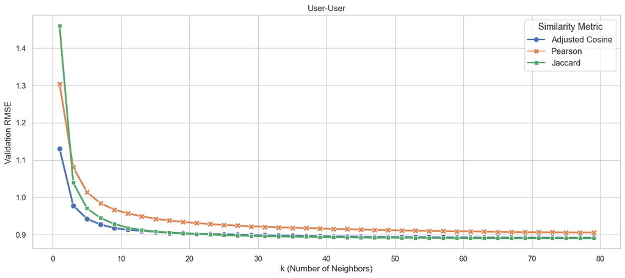

```python
plt.figure(figsize=(15, 6))

lineplot = sns.lineplot(
    data=df_long,
    x='k',
    y='Validation RMSE',
    hue='Similarity Metric',
    style='Similarity Metric',
    markers=True,
    dashes=False,
    markersize=8,
    linewidth=2.5
)

plt.title('User-User')
plt.xlabel('k (Number of Neighbors)')
plt.ylabel('Validation RMSE')

plt.legend(title='Similarity Metric', loc='upper right', fontsize='medium', title_fontsize='13')

plt.grid(True)

# Show the plot
plt.show()
```

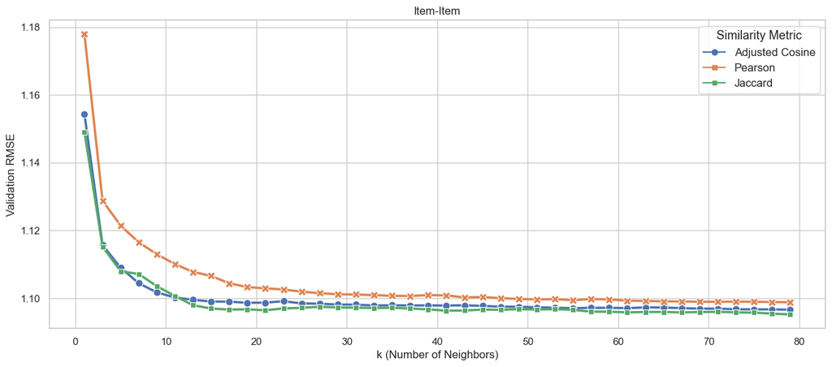

```python
k_values = range(1, 80, 2)

# RMSE values for each similarity metric
adjusted_cosine_rmse = [
    1.154380049620518, 1.1156997630374736, 1.1090104675711467, 1.1044183088153243, 1.1017253175273265,
    1.1002152302186177, 1.0995318555426588, 1.0990231798847072, 1.0989855226369636, 1.0986548855098002,
    1.098701779768074, 1.0991216131773065, 1.098471086962698, 1.0983801623562834, 1.0981313848176395,
    1.0981241262749168, 1.0978378838037086, 1.0979199668555217, 1.0978636380939797, 1.0978871855570722,
    1.0978444255269575, 1.0979019197262743, 1.0977430501388585, 1.097507882762967, 1.0974790845308846,
    1.0973150798435842, 1.0971970152792787, 1.0970593163342404, 1.0971706932653962, 1.097169645771301,
    1.0970821376079403, 1.0972924448432548, 1.0972485177312037, 1.0970793815169195, 1.0969342517255483,
    1.0969204479525037, 1.096761822423318, 1.0967095313681332, 1.0967107730170291, 1.096610576364337
]

pearson_rmse = [
    1.1779214819485897, 1.1287985082982503, 1.1214292857028216, 1.1165080176902829, 1.1129670065338522,
    1.1100754419258057, 1.1077540556090553, 1.1065993919789263, 1.104394816124787, 1.1032964624837045,
    1.1029083713141468, 1.102580672877594, 1.101938098483214, 1.1014781731731622, 1.1011782728839477,
    1.1010864664355633, 1.1009166819786012, 1.100702404553919, 1.1006756173479222, 1.1009142927530362,
    1.1008448760764582, 1.100249451919166, 1.1003533950233297, 1.1000276524240398, 1.099791900032279,
    1.099648462661164, 1.099730788239545, 1.0994513302915307, 1.0997507096941228, 1.0996514992973758,
    1.099290145292876, 1.0991993315627209, 1.0991008629631291, 1.0990396649604872, 1.098971063837134,
    1.098956843030781, 1.0989982537924816, 1.0989699057269395, 1.0988928308243715, 1.0988031433213465
]

jaccard_rmse = [
    1.1490587970318096, 1.11523536677881, 1.1079526610773045, 1.107143265280513, 1.1035578341224235,
    1.1006560921447317, 1.0979338104362935, 1.0969622207265917, 1.096649995450921, 1.0967265942149735,
    1.0964410980144745, 1.0969961412653946, 1.0971547777842898, 1.0974902173363592, 1.0972548368618413,
    1.0972270248517497, 1.097091217169658, 1.0971915908024386, 1.096960320859073, 1.0967094937645008,
    1.0963186299567176, 1.096374441616107, 1.0966524130169768, 1.0965740735107095, 1.0967741077142836,
    1.0966549637871585, 1.0967613279117499, 1.0965679328375995, 1.0960432142299983, 1.0960136416653663,
    1.0958285874679146, 1.0959342762887911, 1.0959442279293974, 1.0958197818786242, 1.0959212419817967,
    1.0959843193760406, 1.095830282078758, 1.0957555547649036, 1.095459707896517, 1.0952116125723426
]
data = {
    'k': list(k_values),
    'Adjusted Cosine': adjusted_cosine_rmse,
    'Pearson': pearson_rmse,
    'Jaccard': jaccard_rmse
}
df = pd.DataFrame(data)
df_melted = df.melt(id_vars='k', var_name='Similarity Metric', value_name='Validation RMSE')

plt.figure(figsize=(15, 6))

lineplot = sns.lineplot(
    data=df_melted,
    x='k',
    y='Validation RMSE',
    hue='Similarity Metric',
    style='Similarity Metric',
    markers=True,
    dashes=False,
    markersize=8,
    linewidth=2.5
)

plt.title('Item-Item')
plt.xlabel('k (Number of Neighbors)')
plt.ylabel('Validation RMSE')

plt.legend(title='Similarity Metric', loc='upper right', fontsize='medium', title_fontsize='13')

plt.grid(True)

plt.show()
```